### 3.3. Beats por Minuto

Leemos la data frame

```r
library(readr)
library(dplyr)
TB4 = read_csv("Base de datos limpia.csv")
TB4
```

| title | artist | top genre | bpm | dB | dur | top year |
| --- | --- | --- | --- | --- | --- | --- |
| STARSTRUKK (feat. Katy Perry) | 3OH!3 | dance pop | 140 | -6 | 203 | 2010 |
| My First Kiss (feat. Ke$ha) | 3OH!3 | dance pop | 138 | -4 | 192 | 2010 |
| I Need A Dollar | Aloe Blacc | pop soul | 95 | -7 | 243 | 2010 |
| Airplanes (feat. Hayley Williams of Paramore) | B.o.B | atl hip hop | 93 | -4 | 180 | 2010 |
| Nothin' on You (feat. Bruno Mars) | B.o.B | atl hip hop | 104 | -6 | 268 | 2010 |
| Magic (feat. Rivers Cuomo) | B.o.B | atl hip hop | 82 | -4 | 196 | 2010 |
| The Time (Dirty Bit) | Black Eyed Peas | dance pop | 128 | -8 | 308 | 2010 |
| Imma Be | Black Eyed Peas | dance pop | 92 | -7 | 258 | 2010 |
| Talking to the Moon | Bruno Mars | dance pop | 146 | -5 | 218 | 2010 |
| Just the Way You Are | Bruno Mars | dance pop | 109 | -5 | 221 | 2010 |

[output cut: 990 more lines]

HISTOGRAMA bpm

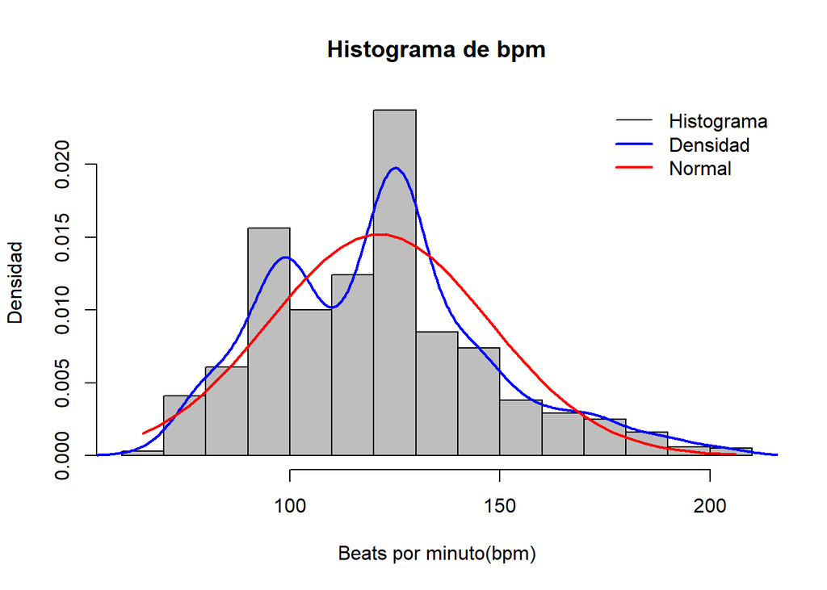

```r
hist(TB4$bpm, breaks = 20, xlab = "Beats por minuto(bpm)", ylab = "Densidad", main="Histograma de bpm", col = "gray", probability = TRUE)
lines(density(TB4$bpm), col = "blue", lwd = 2) # Densidad
x <- seq(min(TB4$bpm), max(TB4$bpm), length = 40)
f <- dnorm(x, mean = mean(TB4$bpm), sd = sd(TB4$bpm))
lines(x, f, col = "red", lwd = 2)#normal
legend("topright", c("Histograma", "Densidad", "Normal"), box.lty = 0,
          lty = 1, col = c("black", "blue", "red"), lwd = c(1, 2, 2))
```

BOXPLOT bpm

[figure not shown]

```r
boxplot(main="BoxPlot bpm" ,xlab="ppm",TB4$bpm, horizontal = TRUE)
segments(x0 = mean(TB4$bpm), y0 = 0.8,
         x1 = mean(TB4$bpm), y1 = 1.2,
         col = "red", lwd = 2)

points(mean(TB4$bpm), 1, col = 3, pch = 19)
par(mfrow = c(1, 1))

legend("topright", c("Diagrama BoxPLot", "Mediana"), box.lty = 0,
          lty = 1, col = c("black", "red"), lwd = c(2, 2))
```

BOXPLOT bpm vs TOP año

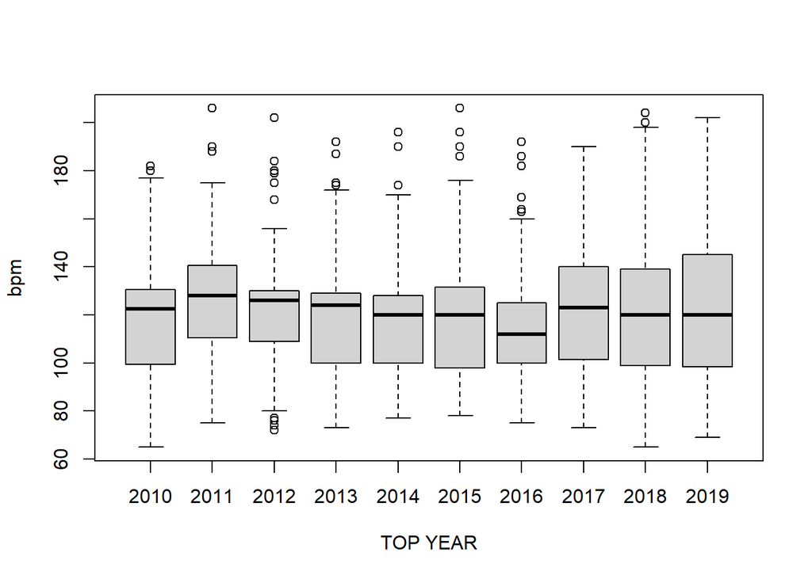

```r
boxplot(TB4$bpm ~ TB4$`top year`, xlab="TOP YEAR", ylab="bpm")
```

En conclusión, la cantidad de bpm está relacionada al tempo musical, La cantidad de golpes determina el ritmo de la música, así los géneros musicales tienen su propio tempo (bpm). Por dicha razón se busca encontrar la relación de esta variable con la popularidad que alcanza cada canción. Poder analizar los rangos de bpm en los que las canciones tienden a popularizarse.

### 3.4. Decibeles

Antes de empezar el análisis de la variable “dB” primero debemos cargar las librerías que vayamos a utilizar, para posteriormente subir y leer la base de datos.

```r
ifelse(require(readr)==T, library(readr))
```

```
## [1] "ggplot2"
```

```r
DFL= read_csv("Base de Datos Limpia.csv")
```

Ahora que tenemos la nueva data, procederemos a calcular el decibel que más se repite en total, así como también su promedio y mediana a lo largo de los años. Esto nos permitirá desarrollar el análisis de manera adecuada.

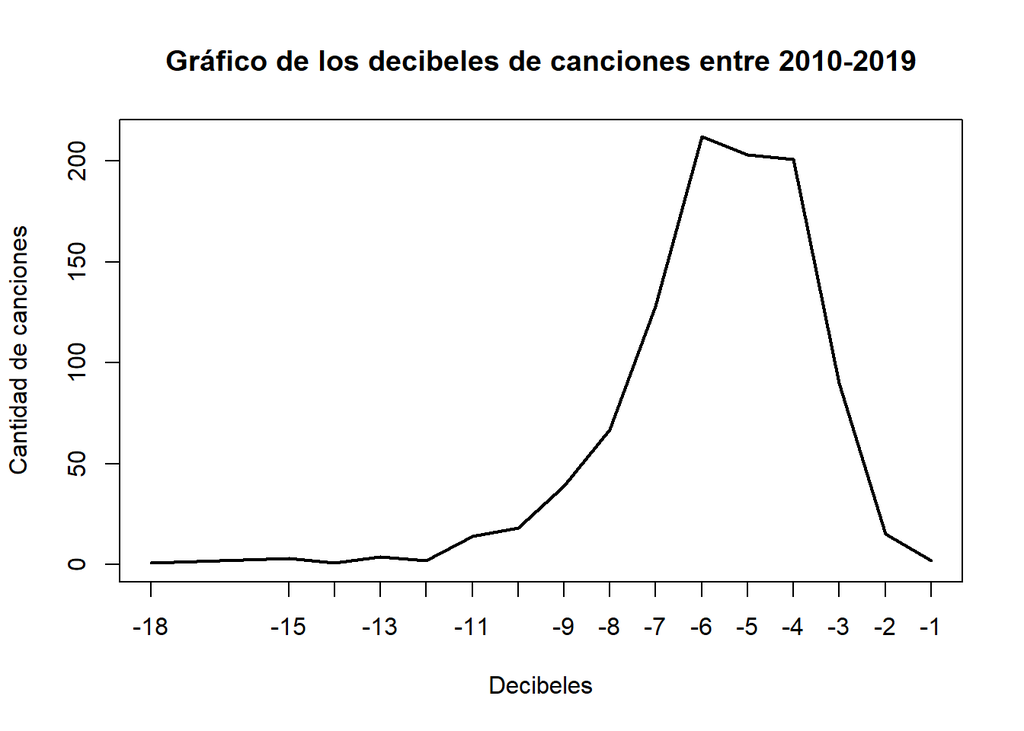

```r
#Moda Total
Frecuencia_dB <- table(DFL$dB) # -6 dB -> 212/1000 -> 21.2%

#Promedio
Promedio_dB <- mean(DFL$dB) # -5.663 dB

#Mediana
Mediana_dB <- median(DFL$dB) # -5 dB

plot(Frecuencia_dB,type="l",main="Gráfico de los decibeles de canciones entre 2010-2019",ylab="Cantidad de canciones",xlab="Decibeles")
```

Asimismo podemos hacer otro gráfico con el porcentaje de apariciones de decibeles por año.

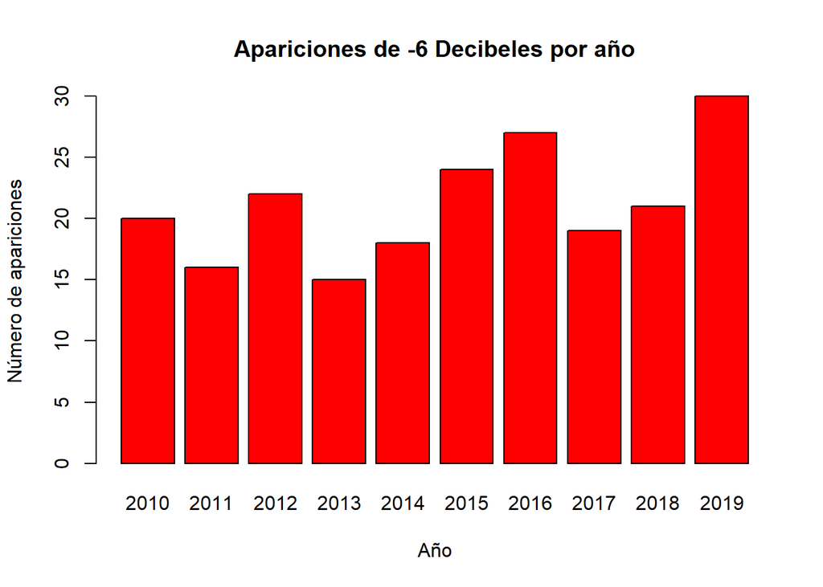

```r
#Gráfico de "decibel" por apariciones por año

a=DFL[DFL$dB== -6,]$dB
b=DFL[DFL$dB== -6,]$`top year`

t=table(a,b)

#Apariciones de -6dB por Año
barplot(t,col="red",main="Apariciones de -6 Decibeles por año",ylab="Número de apariciones",xlab="Año")
```

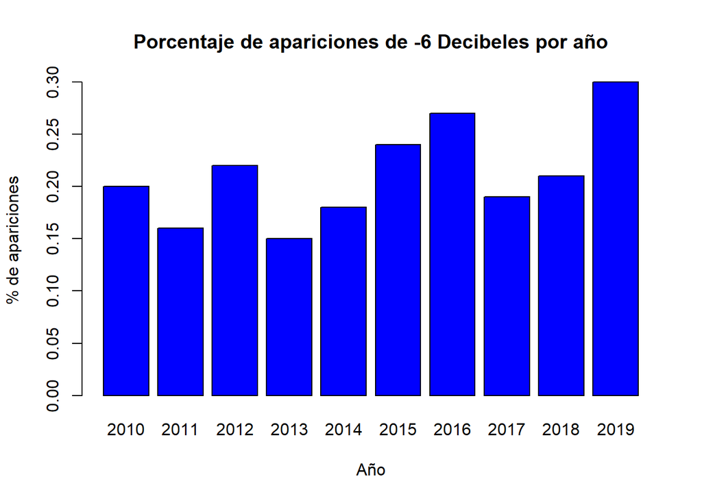

```r
#Porcentaje de apariciones de decibeles por año
barplot(t/100,col="blue", main="Porcentaje de apariciones de -6 Decibeles por año", ylab="% de apariciones",xlab="Año")
```

Después de terminar la investigación y análisis, de la variable dB, realizado previamente hemos llegado a la conclusión que esta variable lo que nos muestra es la variación de decibeles; es decir, si una canción tiene un volumen, lo que hace el valor del dB es modificarlo (atenuar su tono sobre la señal original), por lo que necesitamos saber el valor de entrada y el de salida para que esta variable sea significante en esta investigación. Entonces, lo que en realidad se quería era el valor del tono de la canción para poder analizarlo y relacionarlo con las otras variables que tenemos, pero como hemos comprobado que para teniendo esta gráfica y el análisis previo podemos saber que esta variable no será usada para el proyecto.

### 3.5. Duración

```r
ifelse(require(tidyverse)==T, library(tidyverse))
```

```
## [1] "lubridate"
```

```r
Duracion<- DFL %>% group_by(`top year`) %>% summarise(dur_avg = mean(dur), dur_median = median (dur), dur_cv = sd(dur)/mean(dur), max_dur = max(dur),min_dur=min(dur))%>% arrange(desc(dur_avg))
Duracion
```

| top year | dur_avg | dur_median | dur_cv | max_dur | min_dur |
| --- | --- | --- | --- | --- | --- |
| 2011 | 230.19 | 228.0 | 0.1396923 | 337 | 166 |
| 2013 | 229.49 | 227.0 | 0.2028466 | 484 | 148 |
| 2014 | 227.90 | 218.5 | 0.2489476 | 688 | 165 |
| 2010 | 226.45 | 221.0 | 0.1465899 | 321 | 157 |
| 2012 | 226.38 | 219.0 | 0.1561742 | 350 | 157 |
| 2017 | 221.04 | 216.0 | 0.1695447 | 343 | 119 |
| 2016 | 219.86 | 214.5 | 0.1371912 | 348 | 160 |
| 2015 | 218.46 | 219.0 | 0.1169346 | 284 | 160 |
| 2018 | 208.79 | 203.0 | 0.1968855 | 418 | 122 |
| 2019 | 195.50 | 191.0 | 0.2034202 | 354 | 113 |

```r
Promedio <- mean(Duracion$dur_avg)
Promedio
```

```
## [1] 220.406
```

En esta tabla podemos observar que las 100 canciones top de los últimos 10 años tienen una duración que rondan por 230.19 y 195.50 segundos. Es decir, la tendencia de las canciones top son de duración. Ademas, en promedio la duración de estas rondan los 220.41 segundos, entonces los usuarios de Spotify prefieren canciones cortas que largas como una obra teatral de opera.

```r
Dur_Genero<- DFL %>% group_by(`top genre`) %>% summarise(dur_avg = mean(dur))%>% arrange(desc(dur_avg))
Dur_Genero
```

| top genre | dur_avg |
| --- | --- |
| classic rock | 354.0000 |
| eau claire indie | 337.0000 |
| dutch house | 321.0000 |
| german pop | 314.0000 |
| hollywood | 302.0000 |
| electro | 301.0000 |
| dirty south rap | 276.0000 |
| irish pop | 268.0000 |
| permanent wave | 264.1250 |
| contemporary r&b | 263.0000 |

[output cut: 122 more lines]

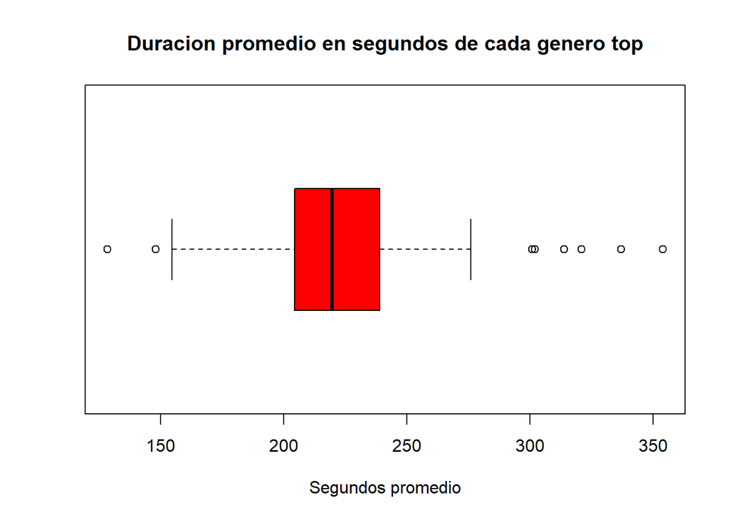

```r
boxplot(Dur_Genero$dur_avg,main="Duracion promedio en segundos de cada genero top",xlab="Segundos promedio",horizontal = TRUE,col = "red")
```

```r
Cuantil_1 <- quantile(Dur_Genero$dur_avg,0.25)
Cuantil_2 <- quantile(Dur_Genero$dur_avg,0.50)
Cuantil_3 <- quantile(Dur_Genero$dur_avg,0.75)
```

La tendencia de duración entre los géneros top en la ultima década esta entre los segundos 204.43 y 239 segundos, los cual es interesante saber que este lapso no es tan corto que un minuto pero tampoco excede los 5 minutos. La mayoría de los géneros top en el periodo de nuestro estudio opta por una duración media, lo suficiente para ser disfrutada por los usuarios de Spotify.

### 4 ANALISIS PROBABILISTICO

### 4.1 Analisis probabilistico entre el numero de canciones del género “dance pop” por playlist anual

Primero, organizamos la información del número de canción del género modal por año, y la guardamos en una tabla así.

```r
library(dplyr)
BDL = read.csv("Base de Datos Limpia.csv")
genero=filter(BDL,BDL$top.genre=="dance pop")
Ta=data.frame(table(genero$top.year))
colnames(Ta) <- c("Año","# de canciones")

Ta
```

| Año | # de canciones |
| --- | --- |
| 2010 | 42 |
| 2011 | 45 |
| 2012 | 37 |
| 2013 | 37 |
| 2014 | 39 |
| 2015 | 38 |
| 2016 | 48 |
| 2017 | 25 |
| 2018 | 28 |
| 2019 | 22 |

Ahora que tenemos organizada nuestra información será más fácil para trabajar, primero empezaremos con:

1. Cual es la probabilidad de que al seleccionar una canción, esta sea de “dance pop”

Para ello sabemos que tenemos 1000 canciones en total, ahora, necesitamos saber cuantas de estas canciones pertenecen al genero dance pop, para ello:

```r
nrow(genero)
```

```
## [1] 361
```

Ahora sabemos que solo 361 canciones son del genero dance pop (género modal), entonces para calcular la probabilidad de que al seleccionar una canción al azar esta sea “dance pop” se calcula dividiendo el numero de canciones dance pop entre el total de canciones, sería:

```r
cat("P(x=Dance pop)=",round(361/1000,2))
```

```
## P(x=Dance pop)= 0.36
```

Vemos que la probabilidad corresponde a casi 0.4, un numero que no sabríamos si decir que es grande o no, para ello procederemos a calcular la probabilidad de cada genero y ponerlo en un boxplot.

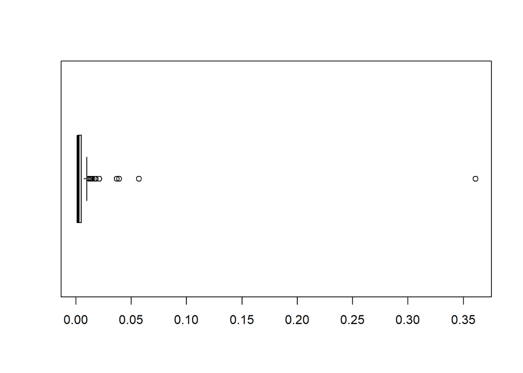

```r
boxplot(table(BDL$top.genre)/nrow(BDL),horizontal=T)
```

en este boxplot podemos ver que hay un dato atípico, el cual se encuentra más a la derecha que el resto, este dato corresponde a la probabilidad de encontrar una cancion dance pop entre las 1000 canciones. de esta manera podemos confirmar cómo se comporta la cancion modal, frente a otras.

2. Ahora vamos a calcular la probabilidad de que al sacar una canción aleatoria en cada playlist, esta sea del genero modal.

```r
aea=BDL
P0=nrow(filter(filter(aea,aea$top.year==2010),filter(aea,aea$top.year==2010)$top.genre=="dance pop"))/nrow(filter(aea,aea$top.year==2010))
P1=nrow(filter(filter(aea,aea$top.year==2011),filter(aea,aea$top.year==2011)$top.genre=="dance pop"))/nrow(filter(aea,aea$top.year==2011))
P2=nrow(filter(filter(aea,aea$top.year==2012),filter(aea,aea$top.year==2012)$top.genre=="dance pop"))/nrow(filter(aea,aea$top.year==2012))
P3=nrow(filter(filter(aea,aea$top.year==2013),filter(aea,aea$top.year==2013)$top.genre=="dance pop"))/nrow(filter(aea,aea$top.year==2013))
P4=nrow(filter(filter(aea,aea$top.year==2014),filter(aea,aea$top.year==2014)$top.genre=="dance pop"))/nrow(filter(aea,aea$top.year==2014))
P5=nrow(filter(filter(aea,aea$top.year==2015),filter(aea,aea$top.year==2015)$top.genre=="dance pop"))/nrow(filter(aea,aea$top.year==2015))
P6=nrow(filter(filter(aea,aea$top.year==2016),filter(aea,aea$top.year==2016)$top.genre=="dance pop"))/nrow(filter(aea,aea$top.year==2016))
P7=nrow(filter(filter(aea,aea$top.year==2017),filter(aea,aea$top.year==2017)$top.genre=="dance pop"))/nrow(filter(aea,aea$top.year==2017))
P8=nrow(filter(filter(aea,aea$top.year==2018),filter(aea,aea$top.year==2018)$top.genre=="dance pop"))/nrow(filter(aea,aea$top.year==2018))
P9=nrow(filter(filter(aea,aea$top.year==2019),filter(aea,aea$top.year==2019)$top.genre=="dance pop"))/nrow(filter(aea,aea$top.year==2019))
```

y lo guardamos en esta tabla, donde tenemos “probabilidad de que sea”dance pop”, dado cada año”

```r
tabla1=data.frame(Año=c(2010:2019),Probabilidad=c(P0,P1,P2,P3,P4,P5,P6,P7,P8,P9))
tabla1
```

| Año | Probabilidad |
| --- | --- |
| 2010 | 0.42 |
| 2011 | 0.45 |
| 2012 | 0.37 |
| 2013 | 0.37 |
| 2014 | 0.39 |
| 2015 | 0.38 |
| 2016 | 0.48 |
| 2017 | 0.25 |
| 2018 | 0.28 |
| 2019 | 0.22 |

Entonces nos plantemos situaciones:

3. Cual es la probabilidad de que al escoger una cancion dance pop, esta sea del 2015
4. Cual es la probabilidad de que al escoger una cancion del 2017, esta no sea del género dance pop.
5. Cual es la probabilidad de que al escoger 1 cancion de cada playlist, TODAS sean del género dance pop.

Lo escribimos en terminos de probabilidad:

3. P(2015|Si)=(P(Si|2015)P(2015))/P(Si) ,

Donde: P(2015|Si)-> probabilidad de que al sacar una cancion del género dance pop, esta sea del 2015.

P(Si|2015)-> probabilidad de que al sacar una cancion del 2015, esta sea del género dance pop.

P(Si)-> probabilidad de que al sacar una cancion, esta sea del género dance pop.

P(2015)-> probabilidad de que al sacar una cancion, esta sea del año 2015.

Entonces cumpliendo con los calculos tenemos:

```r
cat("P(2015|Si)=",round((0.38*0.1)/0.361,2))
```

```
## P(2015|Si)= 0.11
```

P(No|2017)-> probabilidad de que al sacar una cancion del 2017, sea no sea del genero dance pop.

P(2017|No)-> probabilidad de que al sacar una cancion que no es del genero dance pop, sea del 2017.

P(2017)-> probabilidad de que al sacar una canción, esta sea del 2017.

P(No)-> probabilidad de que al sacar una canción, esta no sea del genero dance pop.

Entonces cumpliendo con los calculos tenemos:

```r
cat("P(No|2017)=",round((0.75*0.1)/0.639,2))
```

[output not shown]

```r
cat("P =",0.1*(sum(tabla1$Probabilidad)))
```

```
## P = 0.361
```

### 4.2 Analisis probabilistico entre el BPM, el género modal y la nacionalidad del artista de la canción.

Primero leeremos la base de datos limpia que tenemos y obtenemos los bom más concurridos en el género dance pop, para poder trabajar mejor con la información

```r
library(readr)
BDL = read_csv("Base de Datos Limpia.csv")
a=BDL[BDL$`top genre`=="dance pop",]$`top genre`
b=BDL[BDL$`top genre`=="dance pop",]$bpm
t=table(b,a)
```

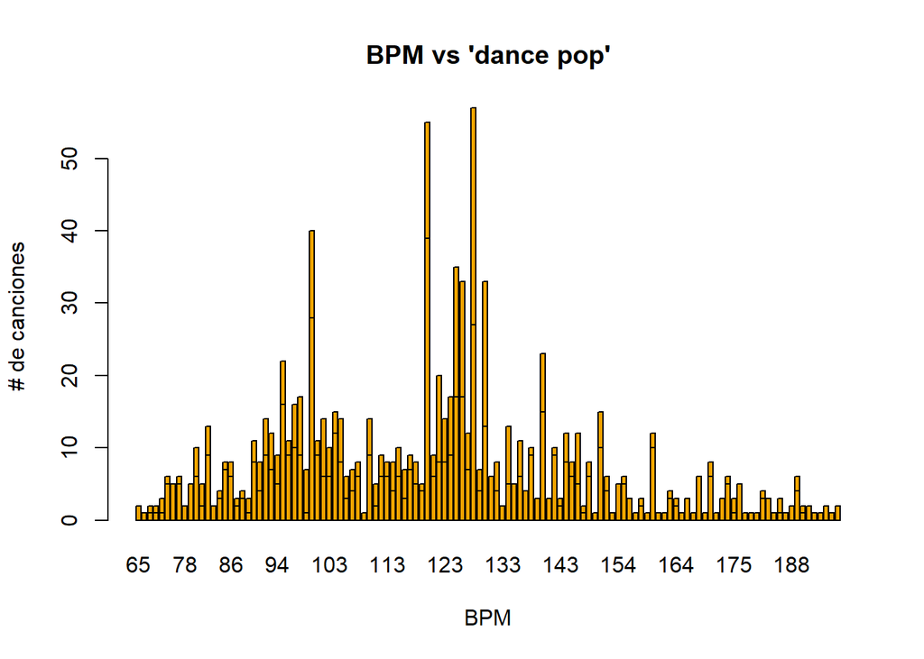

```r
tabla2 = table(BDL$`top genre`=="dance pop",BDL$bpm)
barplot(tabla2,main="BPM vs 'dance pop'",ylab="# de canciones",xlab="BPM",col="orange")
```

Como el género que más destaca es dance pop, buscamos las canciones que usan 128 bpm, las cuales son 30 canciones,

```r
BD_DancePop_Bpm = BDL[BDL$`top genre` == "dance pop" & BDL$bpm == 128,]
BD_DancePop_Bpm
```

| title | artist | top genre | bpm | dB | dur | top year |
| --- | --- | --- | --- | --- | --- | --- |
| The Time (Dirty Bit) | Black Eyed Peas | dance pop | 128 | -8 | 308 | 2010 |
| Club Can't Handle Me (feat. David Guetta) | Flo Rida | dance pop | 128 | -4 | 235 | 2010 |
| Hot - Malibu Breeze Radio Edit | INNA | dance pop | 128 | -8 | 224 | 2010 |
| Bounce (feat. Kelis) - Radio Edit | Calvin Harris | dance pop | 128 | -2 | 222 | 2011 |
| Beautiful People | Chris Brown | dance pop | 128 | -6 | 226 | 2011 |
| Hey Baby (Drop It to the Floor) (feat. T-Pain) | Pitbull | dance pop | 128 | -3 | 234 | 2011 |
| Higher | Taio Cruz | dance pop | 128 | -5 | 188 | 2011 |
| Years | Alesso | dance pop | 128 | -6 | 195 | 2012 |
| Silhouettes - Original Radio Edit | Avicii | dance pop | 128 | -6 | 212 | 2012 |
| Feel So Close - Radio Edit | Calvin Harris | dance pop | 128 | -3 | 206 | 2012 |

[output cut: 20 more lines]

De todas las 30 canciones listadas, ¿Cuál crees que sería la probabilidad de que se escoja un artista al azar y sea de nacionalidad Norte Americana? Primero procederemos a agregar una nueva variable “Artist_Origen” para sí poder colocar la nacionalidad correspondiente a cada artista o banda.

```r
Artist_Origen = c("EEUU","EEUU","Rumanía","Reino Unido","EEUU","EEUU","Reino Unido","Suecia","Suecia","Reino Unido","Reino Unido","Reino Unido","EEUU","EEUU","Suecia","EEUU","Reino Unido","Reino Unido","Reino Unido","EEUU","Países Bajos","Suecia","EEUU","Reino Unido","Reino Unido","EEUU","Suecia","Reino Unido","EEUU","EEUU")
Copia_BDL = BD_DancePop_Bpm
Copia_BDL = cbind(Copia_BDL,Artist_Origen)
Copia_BDL
```

| title | artist | top genre | bpm | dB | dur | top year | Artist_Origen |
| --- | --- | --- | --- | --- | --- | --- | --- |
| The Time (Dirty Bit) | Black Eyed Peas | dance pop | 128 | -8 | 308 | 2010 | EEUU |
| Club Can't Handle Me (feat. David Guetta) | Flo Rida | dance pop | 128 | -4 | 235 | 2010 | EEUU |
| Hot - Malibu Breeze Radio Edit | INNA | dance pop | 128 | -8 | 224 | 2010 | Rumanía |
| Bounce (feat. Kelis) - Radio Edit | Calvin Harris | dance pop | 128 | -2 | 222 | 2011 | Reino Unido |
| Beautiful People | Chris Brown | dance pop | 128 | -6 | 226 | 2011 | EEUU |
| Hey Baby (Drop It to the Floor) (feat. T-Pain) | Pitbull | dance pop | 128 | -3 | 234 | 2011 | EEUU |
| Higher | Taio Cruz | dance pop | 128 | -5 | 188 | 2011 | Reino Unido |
| Years | Alesso | dance pop | 128 | -6 | 195 | 2012 | Suecia |
| Silhouettes - Original Radio Edit | Avicii | dance pop | 128 | -6 | 212 | 2012 | Suecia |
| Feel So Close - Radio Edit | Calvin Harris | dance pop | 128 | -3 | 206 | 2012 | Reino Unido |

[output cut: 20 more lines]

Primero observamos cuantas veces aparece EEUU

```r
table(Copia_BDL$Artist_Origen)
```

```
##
##         EEUU Países Bajos  Reino Unido      Rumanía       Suecia
##           12            1           11            1            5
```

Observamos que las probabilidades no son iguales (espacio no equiprobable) y qué es más probable que se seleccione una canción cuyo artista es de los Estados Unidos

```r
Prob_EEUU = (12/30)
cat("Prob de sacar un artista EE.UU:",Prob_EEUU)
```

```
## Prob de sacar un artista EE.UU: 0.4
```

Hemos visto que la moda de BPM dentro del genero dance pop es 128 bpm. *¿Es esto verdad para la población general?*

```r
getmode <- function(v) {
   uniqv <- unique(v)
   uniqv[which.max(tabulate(match(v, uniqv)))]}

cat("Moda:",getmode(BDL$bpm))
```

```
## Moda: 128
```

```r
#nrow(BDL[BDL$bpm == 128,])
```

Se puede ver que la moda sigue siendo 128bp. *¿Cual es la probabilidad de que una canción tenga 128 bpm? ¿Como cambia la probabilidad de que tenga este bpm si se observan años específicos?*

```r
Probabilidad <- c(y2010bpm128 <- nrow(BDL[BDL$`top year` == "2010" & BDL$bpm == 128,])/100,
y2011bpm128 <- nrow(BDL[BDL$`top year` == "2011" & BDL$bpm == 128,])/100,
y2012bpm128 <- nrow(BDL[BDL$`top year` == "2012" & BDL$bpm == 128,])/100,
y2013bpm128 <- nrow(BDL[BDL$`top year` == "2013" & BDL$bpm == 128,])/100,
y2014bpm128 <- nrow(BDL[BDL$`top year` == "2014" & BDL$bpm == 128,])/100,
y2015bpm128 <- nrow(BDL[BDL$`top year` == "2015" & BDL$bpm == 128,])/100,
y2016bpm128 <- nrow(BDL[BDL$`top year` == "2016" & BDL$bpm == 128,])/100,
y2017bpm128 <- nrow(BDL[BDL$`top year` == "2017" & BDL$bpm == 128,])/100,
y2018bpm128 <- nrow(BDL[BDL$`top year` == "2018" & BDL$bpm == 128,])/100,
y2019bpm128 <- nrow(BDL[BDL$`top year` == "2019" & BDL$bpm == 128,])/100,

yTotalbpm128 <- nrow(BDL[BDL$bpm == 128,])/1000)

year <- c('2010', '2011', '2012','2013', '2014', '2015', '2016', '2017', '2018', '2019', 'Total')
bpm128 <- data.frame(year, Probabilidad)
bpm128
```

| year | Probabilidad |
| --- | --- |
| 2010 | 0.040 |
| 2011 | 0.110 |
| 2012 | 0.130 |
| 2013 | 0.130 |
| 2014 | 0.060 |
| 2015 | 0.050 |
| 2016 | 0.010 |
| 2017 | 0.010 |
| 2018 | 0.030 |
| 2019 | 0.000 |

[output cut: 1 more lines]

La probabilidad de que una canción tenga 128 bpm es del 6% aproximadamente. La probabilidad cambia de año en año, aunque la probabilidad aumenta durante los años del 2011-2013, donde más del 10% tienen este bpm

### 5. MODELOS

### 5.1 Hypergeométrico

Anteriormente observamos el grupo de canciones con el bpm más comun del genero más comun. Vimos que era un grupo muy reducido, Qué tan reducido se siente?

Para darnos la idea de esto hagamos un experimento hypergeometrico. Escojamos 30 de las canciones, que es digamos el tamaño de una playlist normal y veamos si al menos 1 de estas es de nuestro grupo elegido

```r
HgExperimento <- 1-phyper(0, 30, 1000-30, 30)
HgExperimento
```

```
## [1] 0.6044605
```

#Podemos ver de que aunque el grupo sea bastante reducido, si empiezas a escojer varias canciones es más probable encontrarte una de las 30 que no hacerlo

### 5.2 Analizando si existe una relación normal en la duraciones de las canciones del género dance pop.

Para determinar que sigue una distribución normal hicimos 3 métodos:

Primero gráficamos la frecuencia de las duraciones de las canciones del género dance pop

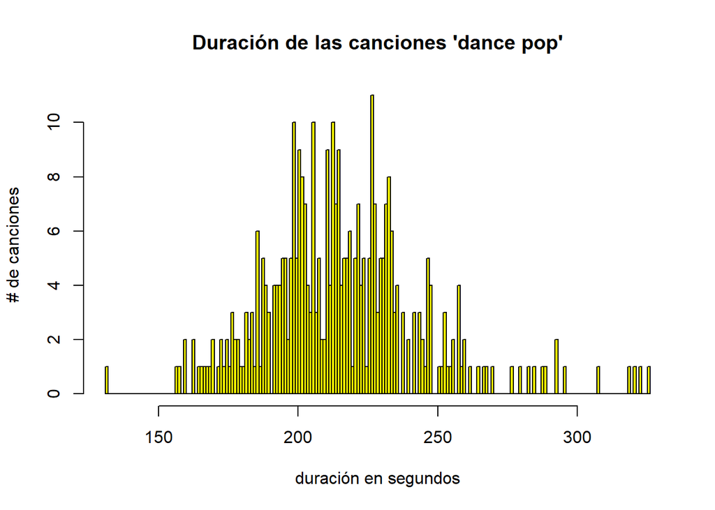

```r
BDL = read.csv("Base de Datos Limpia.csv")
# Grafica data
g=BDL[BDL$top.genre=="dance pop" & BDL$dur<350,]$dur

# Grafica
hist(g,breaks = 200,main="Duración de las canciones 'dance pop'",ylab="# de canciones",xlab="duración en segundos",col="yellow")
```

Vemos que podría asemejarse a una gráfica de distribución normal, pero, ¿qué tanto?, para ello vamos a comparar ambas gráficas

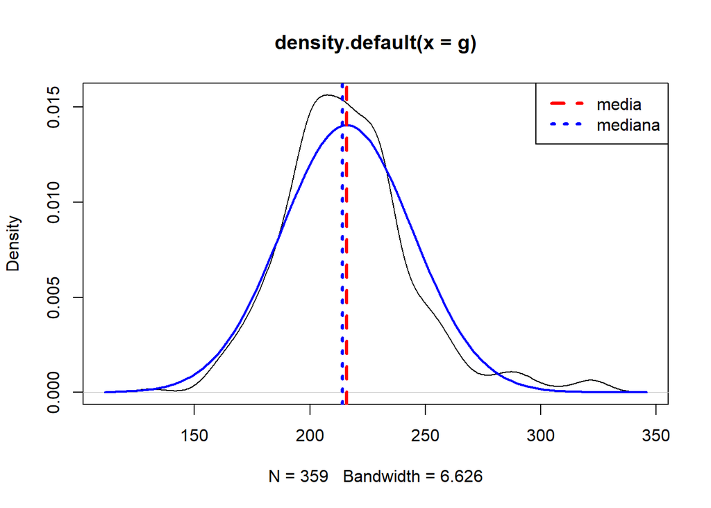

```r
# Probando la normalidad gráficamente comparando la normal con la densidad
# densidad
plot(density(g))
# normal
curve(dnorm(x,mean=mean(g),sd=sd(g)),
      add=TRUE, col="blue", lwd=2)
abline(v=mean(g),col="red", lwd=3, lty=2)
abline(v=median(g),col="blue", lwd=3, lty=3)
legend(x = "topright",legend = c("media", "mediana"),lty = c(2, 3),col = c("red", "blue"),lwd = 3)
```

Otra forma de probar si existe la normalidad es con gráficos de cuantíles teóricos

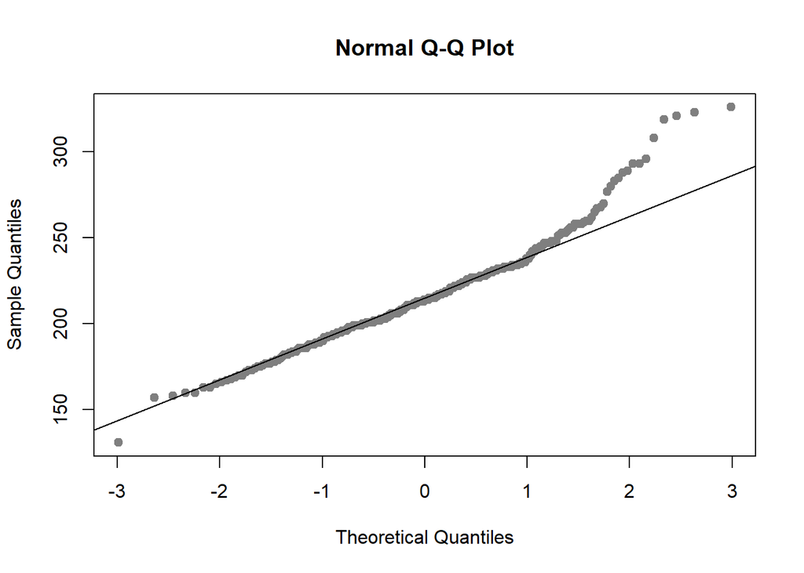

```r
qqnorm(g, pch = 19, col = "gray50")
qqline(g)
```

Con la distribución de cuantiles teóricos, desde -2 a 1 se observa claramente que cumple con la distribución normal.

Medidas importantes:

```r
cat("Media=",mean(g),"\n")
```

```
## Media= 216.0084
```

```r
cat("Mediana=",median(g),"\n")
```

```
## Mediana= 214
```

```r
cat("Desviacion estandar=",sd(g),"\n")
```

```
## Desviacion estandar= 28.38822
```

```r
cat("Dominio=",length(g),"\n")
```

```
## Dominio= 359
```

Para ello usaremos: P(204.43≤X≤239)= P(X<=239)-P(X<=204.43), obteniendo

```r
#X≈N(216.0084,28.38822)
# P(204.43≤X≤239)= P(X<=239)-P(X<=204.43)
pnorm(239,mean(g),sd(g))-pnorm(204.43,mean(g),sd(g))
```

```
## [1] 0.4493124
```

Graficamos la región entre estos dos intervalos

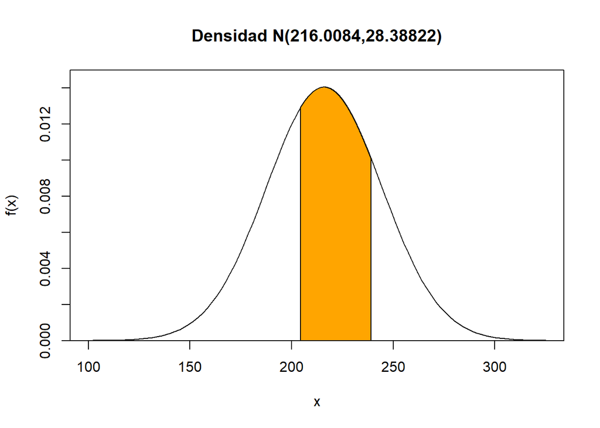

```r
regionX=seq(204.43,239,0.01)
xP <- c(204.43,regionX,239)
yP <- c(0,dnorm(regionX,mean(g),sd(g)),0)
curve(dnorm(x,mean(g),sd(g)),xlim=c(100,325),yaxs="i",ylim=c(0,0.015),ylab="f(x)",
      main='Densidad N(216.0084,28.38822)')
polygon(xP,yP,col="orange1")
box()
```

### 5.3 Distribuición Binomial

*Según el IFPI MUSIC LISTENING 2019, el género más escuchó fue el Pop (120-140BPM), conociendo la relación que existe entre el género y los BPM de cada canción, analizaremos la probabilidad de que una canción elegida al azahar se encuentre en dicho rango.y además en américa latina el 57% de las canciones escuchadas es el POP, eso quiere decir que presenta una probabilidad de Pl=0.57 (probabilidad música pop en américa latina)*

De nuestra base de datos de la variable bpm se contará la cantidad de datos que se se encuentran entre los valores de 120 y 140 bpm para obtener su probabilidad, con respecto a toda la muestra.

**A continuación se encontramos la probabilidad global “P”.**

```r
 #(probabilidad música pop en américa latina)
pl=0.57
#probabilidad global
DBL=BDL
pop<-sum(DBL$bpm>=120 & DBL$bpm<=140, na.rm=TRUE)
p<-(pop/1000)

cat("P(119<x<141)=",p)
```

```
## P(119<x<141)= 0.377
```

*Para analizar la distribución binomial de acuerdo al planteamiento anterior se escogen las 60 primeras canciones de nuestra variable bpm y nos planteamos las siguientes preguntas:*

**1)¿Cual es la probabilidad de que 25 pertenezcan al género Pop, es decir se encuentra en un rango de 120 a 140 BPM?**

Con ayuda de la función **dbinom** encontramos las probabilidades de que el suceso ocurra, tanto para la probabilidad global como para la de américa latina.

```r
x=25
cat("Probabilidad global: ",dbinom(x, 60,p, log=FALSE ),"\n")#probabilidad global
```

```
## Probabilidad global:  0.08529271
```

```r
cat("Prob. America latina: ",dbinom(x,60,pl, log=FALSE))#probabilidad américa latina
```

```
## Prob. America latina:  0.006075246
```

**Gráfica** de la **función de probabilidad binomial**, el comportamiento de las probabilidades para un rango de sucesos de la cantidad de éxitos **X=[1,60]**, se compara la probabilidad global y la de América latina.

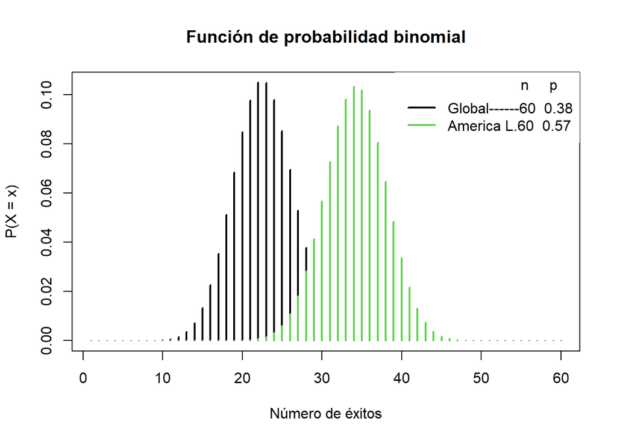

```r
plot(dbinom(x=1:60, size = 60, p), type = "h", lwd = 2,
     main = "Función de probabilidad binomial",
     ylab = "P(X = x)", xlab = "Número de éxitos")


lines(dbinom(x=1:60, size = 60, prob = 0.57), type = "h",
      lwd = 2, col = 3)


#lines(dbinom(x=1:60, size = 60, prob = 0.2), type = "h",
      #lwd = 2, col = rgb(0, 1, 0, 0.7))

# Añadimos una leyenda
legend("topright", legend = c("Global------60  0.38", "America L.60  0.57"),
      title = "n     p", title.adj = 0.85,
       lty =1, col =c(1, 3), lwd = 2, box.lty = 0)
```

**2)¿Cual es la probabilidad de que a lo más 30 pertenezcan al género Pop?**

Para responder a la pregunta ahora se utiliza la función **pbinom** , donde el número de éxitos debe ser menor o igual a 30. Se calcula tan to para “p” como para “pl”.

```r
cat("Prob global: ",pbinom(30, size = 60, prob =p),"\n")
```

```
## Prob global:  0.9809132
```

```r
cat("Prob américa latina: ",pbinom(30, size = 60, prob = pl))
```

```
## Prob américa latina:  0.1672203
```

**Gráfica de la función de probabilidad binomial**, para esta situación se crea una función que grafique de un color para los casos que cumplen con la condición y de otro color los que no. En la gráfica se observa que la cantidad de datos que cumplen con la condición es mayoritaria, lo que se corrobora con el resultado de la probabilidad encontrado en el apartado anterior.

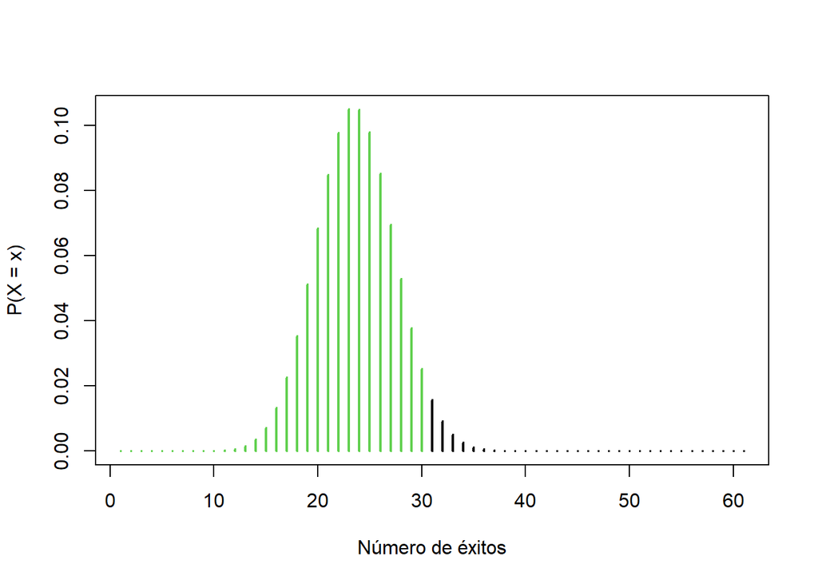

```r
binom_sum <- function(size, prob, lb, ub, col = 4, lwd = 1) {
    x <- 0:size

    if (missing(lb)) {
       lb <- min(x)
    }
    if (missing(ub)) {
        ub <- max(x)
    }

    plot(dbinom(x, size = size, prob = prob), type = "h", lwd = lwd,
         ylab = "P(X = x)", xlab = "Número de éxitos")

    if(lb == min(x) & ub == max(x)) {
        color <- col
    } else {
        color <- rep(1, length(x))
        color[(lb + 1):ub ] <- col
    }

    lines(dbinom(x, size = size, prob = prob), type = "h",
          col =  color, lwd = lwd)
}

binom_sum(size=60, prob=p,ub=30,lwd=2, col=3)
```

**3)¿Cual es la probabilidad de que entre 20 y 25 canciones pertenezcan al género Pop?**

Se obtine la probabilidad con la función **pbinom** tanto para “p” como para “pl”

```r
cat("Prob global: ",pbinom(25, size = 60, prob = p) - pbinom(20, size = 60, prob = p),"\n")
```

```
## Prob global:  0.4908569
```

```r
cat("Prob américa latina: ",pbinom(25, size = 60, prob = 0.57) - pbinom(20, size = 60, prob = 0.57))
```

```
## Prob américa latina:  0.01182905
```

**La Gráfica muestra las probabilidades de los casos que cumplen con la condición.**

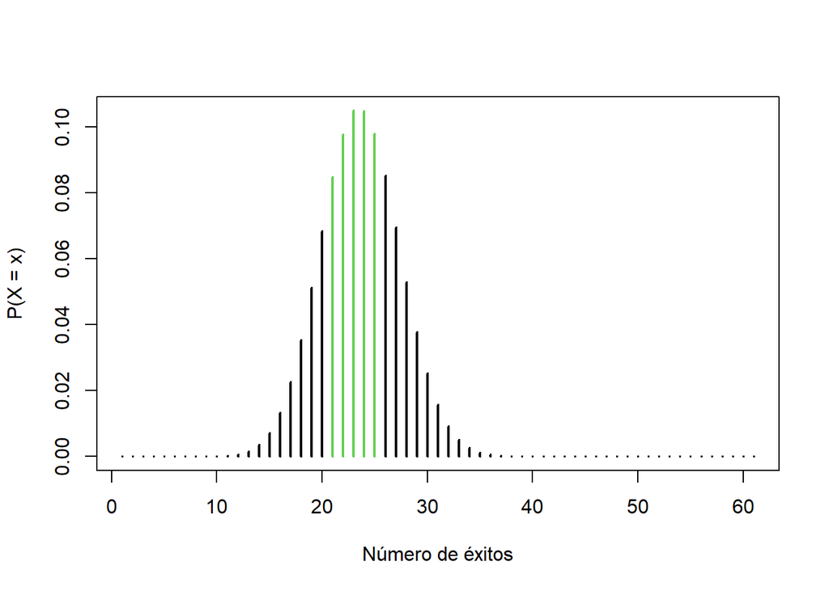

```r
binom_sum(size=60,prob=p,lb=20,ub=25,lwd=2, col=3)
```

**Gráfica probabilidad acumulada**, se muestra la función de las probabilidades acumuladas de “P” y “pl”.

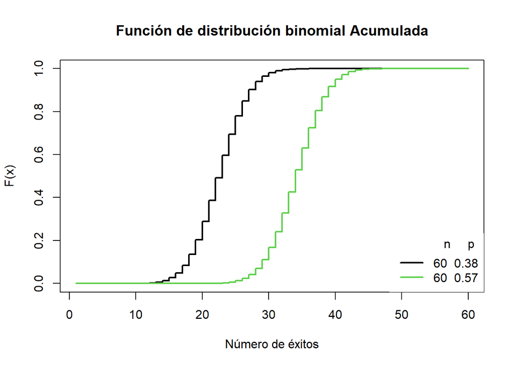

```r
x <- 1:60

plot(pbinom(x, size = 60, prob = p), type = "s", lwd = 2,
     main = "Función de distribución binomial Acumulada",
     xlab = "Número de éxitos", ylab = "F(x)")


lines(pbinom(x, size = 60, prob = 0.57), type = "s",
      lwd = 2, col = 3)

legend("bottomright", legend = c("60  0.38", "60  0.57"),
       title = "n     p", title.adj = 0.85,
       lty = 1, col = c(1,3), lwd = 2, box.lty = 0)
```

**Gráfica de los cantilies por probailidad**, se muestra la distribuición de cada probabilidad por cuantiles.

[figure not shown]

```r
plot(qbinom(seq(0, 1, 0.001), size = 60, prob = p),
     main = "Función binomial cuantil",
     ylab = "Q(p)", xlab = "p",
     type = "s", col = 3, xaxt = "n")
axis(1, labels = seq(0, 1, 0.1), at = 0:10 * 100)

# size = 80, prob = 0.3
lines(qbinom(seq(0, 1, 0.001), size = 80, prob = 0.57), type = "s", col = 2)

legend("topleft", legend = c("60  0.38", "60  0.57"),
       title = "n     p", title.adj = 0.85,
       lty = 1, col = c(3,2), lwd = 2, box.lty = 0)
```